# TUD FOR WEEKDAYS

Kakau with minor amendments from Ben :-)

Last run at: 2020-03-13 12:22:06

```r
# packages ----
library(plyr)
library(stringr)
library(tidyverse)
library(tidyr)
library(lubridate)
library(kableExtra)
library(dplyr)
library(scales)
```

```r
library(ggplot2)

# parameters ----
dPath <- "/Volumes/hum-csafe/Research Projects/FoliakiPhD/tudData/" # edit for your set up
dataF <- path.expand(paste0(dPath, "TUD Weekdays.csv"))
```

#Time Use Diary

The dataframe is a wide format. I had to clean the data by correcting typo and translating some of the data into english. So the file is not as original as it is when export from qualtrics.

```r
# read in my dataframe
weekdays <- read.csv(dataF, na.strings=c(""), check.names = FALSE, header = TRUE, as.is=TRUE)

head(weekdays)
```

```
##     Village Household ID       Day  3:00 AM  3:30 AM  4:00 AM  4:30 AM  5:00 AM
## 1      Fasi           17    Monday Sleeping Sleeping Sleeping Sleeping Sleeping
## 2      <NA>           NA      <NA>     <NA>     <NA>     <NA>     <NA>     <NA>
## 3     Fanga            2    Monday Sleeping Sleeping Sleeping Sleeping Sleeping
## 4      <NA>           NA      <NA>     <NA>     <NA>     <NA>     <NA>     <NA>
## 5 Fangaloto            7 Wednesday Sleeping Sleeping Sleeping Sleeping Sleeping
## 6      <NA>           NA      <NA>     <NA>     <NA>     <NA>     <NA>     <NA>
##    5:30 AM  6:00 AM         6:30 AM               7:00 AM               7:30 AM
## 1 Sleeping  Woke up       Showering             Breakfast             Breakfast
## 2     <NA>     <NA> Getting dressed                  <NA>                  <NA>
## 3 Sleeping Sleeping        Sleeping               Woke up       Getting dressed
## 4     <NA>     <NA>            <NA>             Showering             Breakfast
## 5 Sleeping Sleeping        Sleeping               Woke up       Feeding animals
## 6     <NA>     <NA>            <NA> Listen to music/radio Listen to music/radio
##                 8:00 AM             8:30 AM 9:00 AM 9:30 AM 10:00 AM 10:30 AM
```

[output cut: 48 more lines]

Converting the wide dataframe to long dataframe for easier analysis

Ive noticed that the time is in a character format rather than date. i need to change it to date

> see below

```r
longweekdays <- weekdays %>%
  gather(Time, Activity, 4:51)

head(longweekdays)
```

```
##     Village Household ID       Day    Time Activity
## 1      Fasi           17    Monday 3:00 AM Sleeping
## 2      <NA>           NA      <NA> 3:00 AM     <NA>
## 3     Fanga            2    Monday 3:00 AM Sleeping
## 4      <NA>           NA      <NA> 3:00 AM     <NA>
## 5 Fangaloto            7 Wednesday 3:00 AM Sleeping
## 6      <NA>           NA      <NA> 3:00 AM     <NA>
```

Sorting the TUD dataframe, Firstly, as you can see previously some respondents do not have a secondary activity (i.e NA). Secondly, the data is sorted by time. I think it would be easier to sorted by Household ID. So here i am sorting the data based on ID number

```r
# sorting my dataframe in accending order based on the Household ID
weekdayOrder <- order(longweekdays$`Household ID`)
head(weekdayOrder)
```

```
## [1]   3 177 351 525 699 873
```

```r
# Applying the sorting order into my "longweekdends" dataframe and call it sortweekends
sortweekdays <- longweekdays[weekdayOrder,]
head(sortweekdays)
```

```
##     Village Household ID    Day    Time Activity
## 3     Fanga            2 Monday 3:00 AM Sleeping
## 177   Fanga            2 Monday 3:30 AM Sleeping
## 351   Fanga            2 Monday 4:00 AM Sleeping
## 525   Fanga            2 Monday 4:30 AM Sleeping
## 699   Fanga            2 Monday 5:00 AM Sleeping
## 873   Fanga            2 Monday 5:30 AM Sleeping
```

```r
names(sortweekdays)
```

```
## [1] "Village"      "Household ID" "Day"          "Time"         "Activity"
```

Here i am seprating the activity columm into a primary activity and a secondary activity

The issue im facing with is the date. It in character and alsoit picked up the current date (2020) rather than the date from the TUD.

> BA: I can’t see a date variable. How would R know which date the diary was completed on?

Im trying to sort the date but it comes back N/A

> see below

```r
# Since both the first and second activiies are in one column, i need to separate them into two columns

#call the number of row in my dataframe for the maximum row for my sequence function
nrow(sortweekdays)
```

```
## [1] 8352
```

```r
#create a new dataframe "newdata" for the primary activity only (all odd rows)
newdata <- sortweekdays[seq(1,8351,2),]
head(newdata)
```

```
##      Village Household ID    Day    Time       Activity
## 3      Fanga            2 Monday 3:00 AM       Sleeping
## 351    Fanga            2 Monday 4:00 AM       Sleeping
## 699    Fanga            2 Monday 5:00 AM       Sleeping
## 1047   Fanga            2 Monday 6:00 AM       Sleeping
## 1395   Fanga            2 Monday 7:00 AM        Woke up
## 1743   Fanga            2 Monday 8:00 AM Walking (work)
```

```r
#create a new datagame "newdata1" for the secondary activity (oall even rows)
newdata1 <- sortweekdays[seq(2,8352,2),]
head(newdata1)
```

```
##      Village Household ID    Day    Time        Activity
## 177    Fanga            2 Monday 3:30 AM        Sleeping
## 525    Fanga            2 Monday 4:30 AM        Sleeping
## 873    Fanga            2 Monday 5:30 AM        Sleeping
## 1221   Fanga            2 Monday 6:30 AM        Sleeping
## 1569   Fanga            2 Monday 7:30 AM Getting dressed
## 1917   Fanga            2 Monday 8:30 AM            Work
```

```r
#since i have separated my two acitvities, i need to merge them into one dataframe
newdata$Activity2 <- newdata1$Activity

kableExtra::kable(head(newdata), caption = "Test merged long form data") %>%
  kable_styling()
```

Table 0.1: Test merged long form data

|  | Village | Household ID | Day | Time | Activity | Activity2 |
| --- | --- | --- | --- | --- | --- | --- |
| 3 | Fanga | 2 | Monday | 3:00 AM | Sleeping | Sleeping |
| 351 | Fanga | 2 | Monday | 4:00 AM | Sleeping | Sleeping |
| 699 | Fanga | 2 | Monday | 5:00 AM | Sleeping | Sleeping |
| 1047 | Fanga | 2 | Monday | 6:00 AM | Sleeping | Sleeping |
| 1395 | Fanga | 2 | Monday | 7:00 AM | Woke up | Getting dressed |
| 1743 | Fanga | 2 | Monday | 8:00 AM | Walking (work) | Work |

> BA: fix the time variable so it looks like and acts like HH:MM

```r
newdata$rawTime <- hms::parse_hm(newdata$Time) # this will only be right for AM
newdata$AM_PM <- stringr::word(newdata$Time, 2) # get the second word of 'Time' which will be AM or PM

# Now use that to add 12 hours to rawTime whenit is actually PM
newdata$fixedTime <- ifelse(newdata$AM_PM =="PM", # if PM
                            newdata$rawTime + (12 * 60 * 60), #  add 12 hours
                            newdata$rawTime # otherwise don't
                            )
newdata$fixedHMS <- hms::as_hms(newdata$fixedTime) # make sure it is in H:M:S format

t <- table(newdata$Time, newdata$AM_PM)
kableExtra::kable(t, caption = "Test time coding") %>%
  kable_styling()
```

Table 0.2: Test time coding

|  | AM | PM |
| --- | --- | --- |
| 1:00 AM | 131 | 0 |
| 1:00 PM | 0 | 131 |
| 1:30 AM | 43 | 0 |
| 1:30 PM | 0 | 43 |
| 10:00 AM | 131 | 0 |
| 10:00 PM | 0 | 131 |
| 10:30 AM | 43 | 0 |
| 10:30 PM | 0 | 43 |
| 11:00 AM | 131 | 0 |
| 11:00 PM | 0 | 131 |
| 11:30 AM | 43 | 0 |
| 11:30 PM | 0 | 43 |
| 12:00 AM | 131 | 0 |
| 12:00 PM | 0 | 131 |
| 12:30 AM | 43 | 0 |
| 12:30 PM | 0 | 43 |
| 2:00 AM | 131 | 0 |
| 2:00 PM | 0 | 131 |
| 2:30 AM | 43 | 0 |
| 2:30 PM | 0 | 43 |
| 3:00 AM | 131 | 0 |
| 3:00 PM | 0 | 131 |
| 3:30 AM | 43 | 0 |
| 3:30 PM | 0 | 43 |
| 4:00 AM | 131 | 0 |
| 4:00 PM | 0 | 131 |
| 4:30 AM | 43 | 0 |
| 4:30 PM | 0 | 43 |
| 5:00 AM | 131 | 0 |
| 5:00 PM | 0 | 131 |
| 5:30 AM | 43 | 0 |
| 5:30 PM | 0 | 43 |
| 6:00 AM | 131 | 0 |
| 6:00 PM | 0 | 131 |
| 6:30 AM | 43 | 0 |
| 6:30 PM | 0 | 43 |
| 7:00 AM | 131 | 0 |
| 7:00 PM | 0 | 131 |
| 7:30 AM | 43 | 0 |
| 7:30 PM | 0 | 43 |
| 8:00 AM | 131 | 0 |
| 8:00 PM | 0 | 131 |
| 8:30 AM | 43 | 0 |
| 8:30 PM | 0 | 43 |
| 9:00 AM | 131 | 0 |
| 9:00 PM | 0 | 131 |
| 9:30 AM | 43 | 0 |
| 9:30 PM | 0 | 43 |

# 1 Weekdays TUD

Here i am trying to seprate the data into days so i can analyse the activities.

```r
#filter newdata dataframe by date using the dplyr

#creating a new dataframe "Monday"
monday <- dplyr::filter(newdata, Day == "Monday")
head(monday)
```

```
##   Village Household ID    Day    Time       Activity       Activity2  rawTime
## 1   Fanga            2 Monday 3:00 AM       Sleeping        Sleeping 03:00:00
## 2   Fanga            2 Monday 4:00 AM       Sleeping        Sleeping 04:00:00
## 3   Fanga            2 Monday 5:00 AM       Sleeping        Sleeping 05:00:00
## 4   Fanga            2 Monday 6:00 AM       Sleeping        Sleeping 06:00:00
## 5   Fanga            2 Monday 7:00 AM        Woke up Getting dressed 07:00:00
## 6   Fanga            2 Monday 8:00 AM Walking (work)            Work 08:00:00
##   AM_PM fixedTime fixedHMS
## 1    AM     10800 03:00:00
## 2    AM     14400 04:00:00
## 3    AM     18000 05:00:00
## 4    AM     21600 06:00:00
## 5    AM     25200 07:00:00
## 6    AM     28800 08:00:00
```

```r
#creating a new dataframe "Tuesday"
tuesday <- dplyr::filter(newdata, Day == "Tuesday")
head(tuesday)
```

```
##     Village Household ID     Day    Time        Activity
## 1 Fangaloto            4 Tuesday 3:00 AM        Sleeping
## 2 Fangaloto            4 Tuesday 4:00 AM        Sleeping
## 3 Fangaloto            4 Tuesday 5:00 AM        Sleeping
## 4 Fangaloto            4 Tuesday 6:00 AM        Sleeping
## 5 Fangaloto            4 Tuesday 7:00 AM        Sleeping
## 6 Fangaloto            4 Tuesday 8:00 AM Getting dressed
##                  Activity2  rawTime AM_PM fixedTime fixedHMS
## 1                 Sleeping 03:00:00    AM     10800 03:00:00
## 2                 Sleeping 04:00:00    AM     14400 04:00:00
## 3                 Sleeping 05:00:00    AM     18000 05:00:00
## 4                 Sleeping 06:00:00    AM     21600 06:00:00
## 5                  Woke up 07:00:00    AM     25200 07:00:00
## 6 Driving (drop relatives) 08:00:00    AM     28800 08:00:00
```

```r
#creating a new dataframe "Wednesday"
wednesday <- dplyr::filter(newdata, Day == "Wednesday")
head(wednesday)
```

```
##     Village Household ID       Day    Time        Activity       Activity2
## 1 Fangaloto            7 Wednesday 3:00 AM        Sleeping        Sleeping
## 2 Fangaloto            7 Wednesday 4:00 AM        Sleeping        Sleeping
## 3 Fangaloto            7 Wednesday 5:00 AM        Sleeping        Sleeping
## 4 Fangaloto            7 Wednesday 6:00 AM        Sleeping        Sleeping
## 5 Fangaloto            7 Wednesday 7:00 AM         Woke up Feeding animals
## 6 Fangaloto            7 Wednesday 8:00 AM Getting dressed  Driving (work)
##    rawTime AM_PM fixedTime fixedHMS
## 1 03:00:00    AM     10800 03:00:00
## 2 04:00:00    AM     14400 04:00:00
## 3 05:00:00    AM     18000 05:00:00
## 4 06:00:00    AM     21600 06:00:00
## 5 07:00:00    AM     25200 07:00:00
## 6 08:00:00    AM     28800 08:00:00
```

```r
#creating a new dataframe "Thursday"
thursday <- dplyr::filter(newdata, Day == "Thursday")
head(thursday)
```

```
##     Village Household ID      Day    Time        Activity       Activity2
## 1 Fangaloto            6 Thursday 3:00 AM        Sleeping        Sleeping
## 2 Fangaloto            6 Thursday 4:00 AM        Sleeping        Sleeping
## 3 Fangaloto            6 Thursday 5:00 AM        Sleeping        Sleeping
## 4 Fangaloto            6 Thursday 6:00 AM        Sleeping        Sleeping
## 5 Fangaloto            6 Thursday 7:00 AM         Woke up Getting dressed
## 6 Fangaloto            6 Thursday 8:00 AM Getting dressed  Driving (work)
##    rawTime AM_PM fixedTime fixedHMS
## 1 03:00:00    AM     10800 03:00:00
## 2 04:00:00    AM     14400 04:00:00
## 3 05:00:00    AM     18000 05:00:00
## 4 06:00:00    AM     21600 06:00:00
## 5 07:00:00    AM     25200 07:00:00
## 6 08:00:00    AM     28800 08:00:00
```

```r
#creating a new dataframe "Friday"
friday <- dplyr::filter(newdata, Day == "Friday")
head(friday)
```

```
##   Village Household ID    Day    Time        Activity      Activity2  rawTime
## 1    Fasi           15 Friday 3:00 AM        Sleeping       Sleeping 03:00:00
## 2    Fasi           15 Friday 4:00 AM        Sleeping       Sleeping 04:00:00
## 3    Fasi           15 Friday 5:00 AM        Sleeping       Sleeping 05:00:00
## 4    Fasi           15 Friday 6:00 AM        Sleeping       Sleeping 06:00:00
## 5    Fasi           15 Friday 7:00 AM        Sleeping        Woke up 07:00:00
## 6    Fasi           15 Friday 8:00 AM Getting dressed Driving (work) 08:00:00
##   AM_PM fixedTime fixedHMS
## 1    AM     10800 03:00:00
## 2    AM     14400 04:00:00
## 3    AM     18000 05:00:00
## 4    AM     21600 06:00:00
## 5    AM     25200 07:00:00
## 6    AM     28800 08:00:00
```

# 2 Monday

So im trying to sort out the coding for Monday so i can copy it for the rest of the weekdays. I’ve did a frequency and proportion of activities for Monday.

```r
#frequency of Activities
freqA <- table(monday$Activity, exclude=NULL)
freqA
```

```
##
##                               Breakfast              Church (social activities)
##                                       7                                       1
##                                 Cooking                      Cooking (business)
##                                      17                                       2
##                         Cooking (lunch)                                  Dinner
##                                       1                                      16
##                        Driving (church)                     Driving (drop kids)
##                                       3                                       2
##                Driving (drop relatives)                          Driving (farm)
##                                       1                                       1
##                           Driving (gym)                          Driving (home)
##                                       8                                      17
##                  Driving (pick up kids)            Driving (visiting relatives)
##                                       5                                       5
##                          Driving (work)                    Exercise (Jog, walk)
##                                      20                                       2
##                         Family devotion       Family time (chatting, games etc)
##                                       5                                       1
##                         Getting dressed                  Getting dressed (kids)
##                                       8                                       3
##             Helping siblings (Homework)                                    Home
##                                       1                                      15
##                         Homework (kids)                                 Ironing
##                                      11                                       1
##                                Ironning                            Kids bedtime
##                                       1                                       3
##                                 Laundry                   Listen to music/radio
##                                       2                                       1
##                  Mobile device (movies)                   Mobile devices (work)
##                                      13                                       6
## Mobile devises (browsing, social media)             Prepare kids bag for school
##                                       8                                       1
##                 Public transport (home)                 Public transport (work)
##                                       1                                       1
##                                 Reading                                    Rest
##                                       4                                       8
##                               Showering                                Sleeping
##                                      14                                     233
##                                 Tidy up           Turning off appliances/Lights
##                                       7                                       1
##                         TV (TV, movies)                      Use mobile devices
##                                      25                                       2
##                          Walking (home)                          Walking (work)
##                                       1                                       3
##                     Wathing movies (TV)                                 Woke up
##                                       1                                      22
##                                    Work
##                                     257
```

```r
dim(freqA)
```

```
## [1] 47
```

```r
#proportion of Activities
propA <- prop.table(freqA)*100
propA <- round(propA, digits=2)
propA
```

```
##
##                               Breakfast              Church (social activities)
##                                    0.91                                    0.13
##                                 Cooking                      Cooking (business)
##                                    2.21                                    0.26
##                         Cooking (lunch)                                  Dinner
##                                    0.13                                    2.08
##                        Driving (church)                     Driving (drop kids)
##                                    0.39                                    0.26
##                Driving (drop relatives)                          Driving (farm)
##                                    0.13                                    0.13
##                           Driving (gym)                          Driving (home)
##                                    1.04                                    2.21
##                  Driving (pick up kids)            Driving (visiting relatives)
##                                    0.65                                    0.65
##                          Driving (work)                    Exercise (Jog, walk)
##                                    2.60                                    0.26
##                         Family devotion       Family time (chatting, games etc)
##                                    0.65                                    0.13
##                         Getting dressed                  Getting dressed (kids)
##                                    1.04                                    0.39
##             Helping siblings (Homework)                                    Home
##                                    0.13                                    1.95
##                         Homework (kids)                                 Ironing
##                                    1.43                                    0.13
##                                Ironning                            Kids bedtime
##                                    0.13                                    0.39
##                                 Laundry                   Listen to music/radio
##                                    0.26                                    0.13
##                  Mobile device (movies)                   Mobile devices (work)
##                                    1.69                                    0.78
## Mobile devises (browsing, social media)             Prepare kids bag for school
##                                    1.04                                    0.13
##                 Public transport (home)                 Public transport (work)
##                                    0.13                                    0.13
##                                 Reading                                    Rest
##                                    0.52                                    1.04
##                               Showering                                Sleeping
##                                    1.82                                   30.34
##                                 Tidy up           Turning off appliances/Lights
##                                    0.91                                    0.13
##                         TV (TV, movies)                      Use mobile devices
##                                    3.26                                    0.26
##                          Walking (home)                          Walking (work)
##                                    0.13                                    0.39
##                     Wathing movies (TV)                                 Woke up
##                                    0.13                                    2.86
##                                    Work
##                                   33.46
```

```r
dim(propA)
```

```
## [1] 47
```

```r
#creating table with binding
tableMon <- cbind(freqA, propA)
tableMon <- cbind(Gender = rownames(tableMon), tableMon)
rownames(tableMon) <- NULL
tableMon
```

```
##       Gender                                    freqA propA
##  [1,] "Breakfast"                               "7"   "0.91"
##  [2,] "Church (social activities)"              "1"   "0.13"
##  [3,] "Cooking"                                 "17"  "2.21"
##  [4,] "Cooking (business)"                      "2"   "0.26"
##  [5,] "Cooking (lunch)"                         "1"   "0.13"
##  [6,] "Dinner"                                  "16"  "2.08"
##  [7,] "Driving (church)"                        "3"   "0.39"
##  [8,] "Driving (drop kids)"                     "2"   "0.26"
##  [9,] "Driving (drop relatives)"                "1"   "0.13"
## [10,] "Driving (farm)"                          "1"   "0.13"
## [11,] "Driving (gym)"                           "8"   "1.04"
## [12,] "Driving (home)"                          "17"  "2.21"
## [13,] "Driving (pick up kids)"                  "5"   "0.65"
## [14,] "Driving (visiting relatives)"            "5"   "0.65"
```

[output cut: 33 more lines]

```r
#rename column names
colnames(tableMon)[colnames(tableMon) == "freqA"] <- "Frequency"
colnames(tableMon)[colnames(tableMon) == "propA"] <- "Proportion (%)"
tableMon
```

```
##       Gender                                    Frequency Proportion (%)
##  [1,] "Breakfast"                               "7"       "0.91"
##  [2,] "Church (social activities)"              "1"       "0.13"
##  [3,] "Cooking"                                 "17"      "2.21"
##  [4,] "Cooking (business)"                      "2"       "0.26"
##  [5,] "Cooking (lunch)"                         "1"       "0.13"
##  [6,] "Dinner"                                  "16"      "2.08"
##  [7,] "Driving (church)"                        "3"       "0.39"
##  [8,] "Driving (drop kids)"                     "2"       "0.26"
##  [9,] "Driving (drop relatives)"                "1"       "0.13"
## [10,] "Driving (farm)"                          "1"       "0.13"
## [11,] "Driving (gym)"                           "8"       "1.04"
## [12,] "Driving (home)"                          "17"      "2.21"
## [13,] "Driving (pick up kids)"                  "5"       "0.65"
## [14,] "Driving (visiting relatives)"            "5"       "0.65"
```

[output cut: 33 more lines]

```r
#using kable extra to create better table format
tableMonday <- kable(tableMon)%>%
  kable_styling(bootstrap_options = "striped", full_width = F)

tableMonday
```

| Gender | Frequency | Proportion (%) |
| --- | --- | --- |
| Breakfast | 7 | 0.91 |
| Church (social activities) | 1 | 0.13 |
| Cooking | 17 | 2.21 |
| Cooking (business) | 2 | 0.26 |
| Cooking (lunch) | 1 | 0.13 |
| Dinner | 16 | 2.08 |
| Driving (church) | 3 | 0.39 |
| Driving (drop kids) | 2 | 0.26 |
| Driving (drop relatives) | 1 | 0.13 |
| Driving (farm) | 1 | 0.13 |
| Driving (gym) | 8 | 1.04 |
| Driving (home) | 17 | 2.21 |
| Driving (pick up kids) | 5 | 0.65 |
| Driving (visiting relatives) | 5 | 0.65 |
| Driving (work) | 20 | 2.6 |
| Exercise (Jog, walk) | 2 | 0.26 |
| Family devotion | 5 | 0.65 |
| Family time (chatting, games etc) | 1 | 0.13 |
| Getting dressed | 8 | 1.04 |
| Getting dressed (kids) | 3 | 0.39 |
| Helping siblings (Homework) | 1 | 0.13 |
| Home | 15 | 1.95 |
| Homework (kids) | 11 | 1.43 |
| Ironing | 1 | 0.13 |
| Ironning | 1 | 0.13 |
| Kids bedtime | 3 | 0.39 |
| Laundry | 2 | 0.26 |
| Listen to music/radio | 1 | 0.13 |
| Mobile device (movies) | 13 | 1.69 |
| Mobile devices (work) | 6 | 0.78 |
| Mobile devises (browsing, social media) | 8 | 1.04 |
| Prepare kids bag for school | 1 | 0.13 |
| Public transport (home) | 1 | 0.13 |
| Public transport (work) | 1 | 0.13 |
| Reading | 4 | 0.52 |
| Rest | 8 | 1.04 |
| Showering | 14 | 1.82 |
| Sleeping | 233 | 30.34 |
| Tidy up | 7 | 0.91 |
| Turning off appliances/Lights | 1 | 0.13 |
| TV (TV, movies) | 25 | 3.26 |
| Use mobile devices | 2 | 0.26 |
| Walking (home) | 1 | 0.13 |
| Walking (work) | 3 | 0.39 |
| Wathing movies (TV) | 1 | 0.13 |
| Woke up | 22 | 2.86 |
| Work | 257 | 33.46 |

## 2.1 Monday TUD

Im trying to see the count for all the activities in the TUD

```r
groupbymonAct <- monday %>%
  dplyr::group_by(Activity) %>%
  dplyr::summarize(count = n())
groupbymonAct
```

```
## # A tibble: 47 x 2
##    Activity                   count
##    <chr>                      <int>
##  1 Breakfast                      7
##  2 Church (social activities)     1
##  3 Cooking                       17
##  4 Cooking (business)             2
##  5 Cooking (lunch)                1
##  6 Dinner                        16
##  7 Driving (church)               3
##  8 Driving (drop kids)            2
##  9 Driving (drop relatives)       1
## 10 Driving (farm)                 1
## # … with 37 more rows
```

Im am trying to remove sleeping, rest, going to work from the data so that i can only focus on the rest of the acitivities.

The issue i am facing as the time is not sorted in accending order. Can you help with the coding

> yep - see what I did :-)

```r
tableAll <- monday %>%
  #select(Time, Activity) %>%
  select(fixedHMS, Activity) %>% # use the new time variable
  filter(Activity != "Sleeping") %>%
  filter(Activity != "Rest") %>%
  filter(Activity != "Work") %>%
  #group_by(Time) %>%
  group_by(fixedHMS) %>%
  tally

kableExtra::kable(tableAll, caption = "Monday test (no sleep/rest/work)") %>%
  kable_styling()
```

Table 2.1: Monday test (no sleep/rest/work)

| fixedHMS | n |
| --- | --- |
| 05:00:00 | 5 |
| 06:00:00 | 13 |
| 07:00:00 | 30 |
| 08:00:00 | 29 |
| 09:00:00 | 3 |
| 10:00:00 | 2 |
| 11:00:00 | 1 |
| 12:00:00 | 4 |
| 13:00:00 | 1 |
| 14:00:00 | 1 |
| 15:00:00 | 2 |
| 16:00:00 | 4 |
| 17:00:00 | 26 |
| 18:00:00 | 25 |
| 19:00:00 | 30 |
| 20:00:00 | 30 |
| 21:00:00 | 29 |
| 22:00:00 | 22 |
| 23:00:00 | 12 |
| 24:00:00 | 1 |

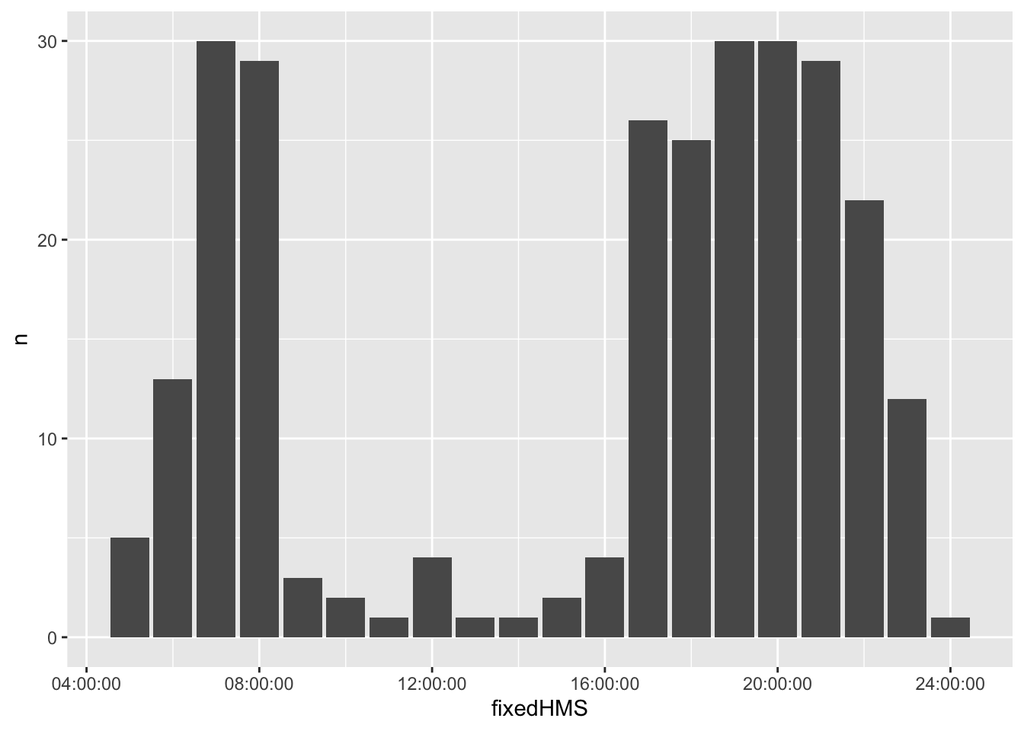

```r
# plot
ggplot2::ggplot(tableAll, aes(x = fixedHMS, y = n)) +
  geom_col()
```

## 2.2 Monday Cooking

Here im am trying to look at anything related to preparing and eating a meal.

```r
# creating dataframe for all cooking

tableCooking <- monday %>%
  select(fixedHMS, Activity) %>%
  filter(Activity != "Sleeping") %>%
  filter(Activity != "Rest") %>%
  filter(Activity != "Work") %>%
  filter(Activity %in% c("Cooking", "Breakfast", "Dinner", "Light meal")) %>%
  group_by(fixedHMS) %>%
  tally


tableCooking
```

```
## # A tibble: 9 x 2
##   fixedHMS     n
##   <time>   <int>
## 1 06:00        2
## 2 07:00        5
## 3 08:00        3
## 4 09:00        1
## 5 17:00        1
## 6 18:00        8
## 7 19:00       10
## 8 20:00        8
## 9 21:00        2
```

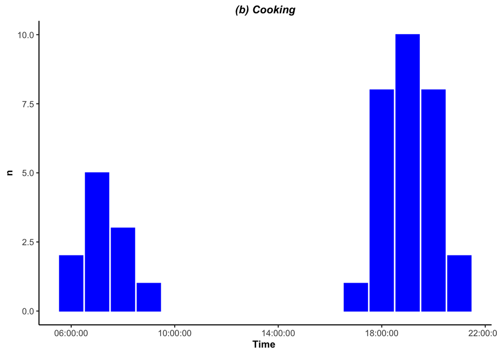

```r
b <- ggplot(tableCooking, aes(x = fixedHMS, y = n)) + geom_bar(stat = "identity", position = "stack", color="blue", fill="blue") +
  ggtitle("(b) Cooking") +
  xlab("Time ") +
  ylab("n") + theme(plot.title = element_text(color="Black", size=11, face="bold.italic", hjust=0.5,lineheight=0.8),
        axis.title.x = element_text(color="black", size=10, face="bold"),
        axis.title.y = element_text(color="black", size=10, face="bold"),
        panel.background=element_rect(fill = "white"),
        panel.grid.minor = element_blank(),
        panel.grid.major = element_blank(),
        axis.line = element_line(colour = "black", size = 1) +
        scale_x_date(labels = date_format("%I:%M %p"))
)

b
```

## 2.3 Monday Tidy up

similar to the above but for tidy up/cleaning up

```r
# creating dataframe for all cleaning up

tableTidyup <- monday %>%
  select(fixedHMS, Activity) %>%
  filter(Activity != "Sleeping") %>%
  filter(Activity != "Rest") %>%
  filter(Activity != "Work") %>%
  filter(Activity %in% c("Tidy up", "Laundry", "Showering", "Getting dressed", "Ironing", "Feeding animals", "Turning off appliances/Lights")) %>%
  group_by(fixedHMS) %>%
  tally


tableTidyup
```

```
## # A tibble: 10 x 2
##    fixedHMS     n
##    <time>   <int>
##  1 06:00        3
##  2 07:00        6
##  3 08:00        6
##  4 09:00        1
##  5 17:00        1
##  6 18:00        4
##  7 19:00        3
##  8 20:00        2
##  9 21:00        4
## 10 22:00        3
```

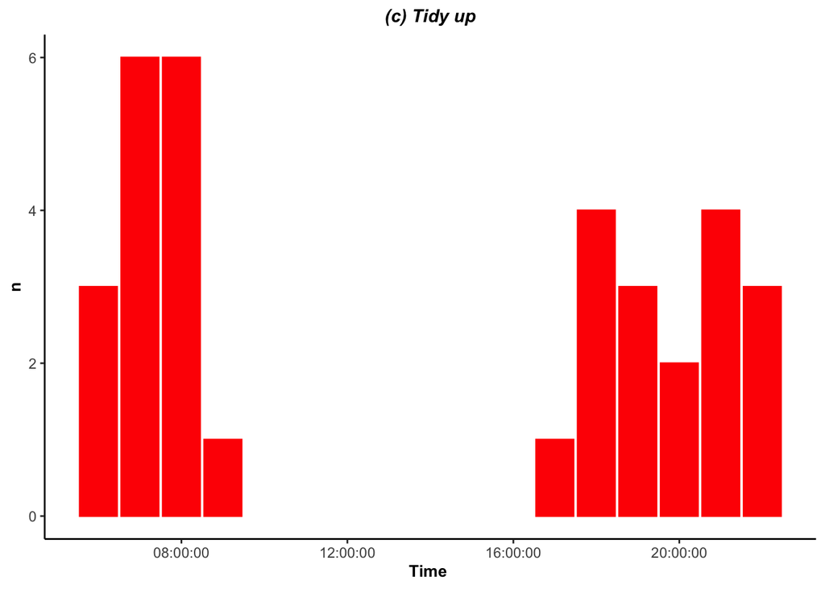

```r
c <- ggplot(tableTidyup, aes(x = fixedHMS, y = n)) + geom_bar(stat = "identity", position = "stack", color="red", fill="red") +
  ggtitle("(c) Tidy up") +
  xlab("Time ") +
  ylab("n") + theme(plot.title = element_text(color="Black", size=11, face="bold.italic", hjust=0.5,lineheight=0.8),
        axis.title.x = element_text(color="black", size=10, face="bold"),
        axis.title.y = element_text(color="black", size=10, face="bold"),
        panel.background=element_rect(fill = "white"),
        panel.grid.minor = element_blank(),
        panel.grid.major = element_blank(),
        axis.line = element_line(colour = "black", size = 1) +
        scale_x_date(labels = date_format("%I:%M %p"))
)

c
```

## 2.4 Monday Leisure

similar to the above but for leisure

```r
# creating dataframe for all leisure

tableleisure <- monday %>%
  select(fixedHMS, Activity) %>%
  filter(Activity != "Sleeping") %>%
  filter(Activity != "Rest") %>%
  filter(Activity != "Work") %>%
  filter(Activity %in% c("TV", "Homework", "Laptop/PC", "Radio", "Mobile phones", "Reading", "Family time")) %>%
  group_by(fixedHMS) %>%
  tally


tableleisure
```

```
## # A tibble: 3 x 2
##   fixedHMS     n
##   <time>   <int>
## 1 12:00        1
## 2 22:00        2
## 3 23:00        1
```

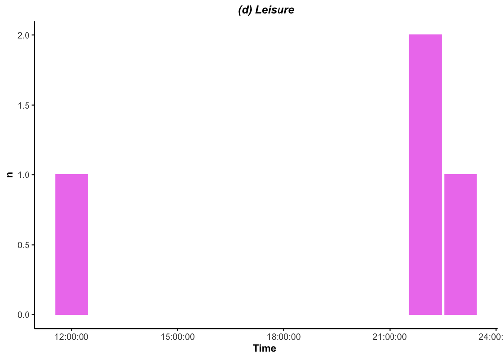

```r
d <- ggplot(tableleisure, aes(x = fixedHMS, y = n)) + geom_bar(stat = "identity", position = "stack", color="violet", fill="violet") +
  ggtitle("(d) Leisure") +
  xlab("Time ") +
  ylab("n") + theme(plot.title = element_text(color="Black", size=11, face="bold.italic", hjust=0.5,lineheight=0.8),
        axis.title.x = element_text(color="black", size=10, face="bold"),
        axis.title.y = element_text(color="black", size=10, face="bold"),
        panel.background=element_rect(fill = "white"),
        panel.grid.minor = element_blank(),
        panel.grid.major = element_blank(),
        axis.line = element_line(colour = "black", size = 1) +
        scale_x_date(labels = date_format("%I:%M %p"))
)

d
```

## 2.5 Monday Away

similar to the above but for away from home

```r
# creating dataframe for Away from Home

tableAway <- monday %>%
  select(fixedHMS, Activity) %>%
  filter(Activity != "Sleeping") %>%
  filter(Activity != "Rest") %>%
  filter(Activity %in% c("Farm", "Relatives", "Work", "Fitness", "Kava", "Church", "Sports", "Going out"))%>%
  group_by(fixedHMS) %>%
  tally


tableAway
```

```
## # A tibble: 15 x 2
##    fixedHMS     n
##    <time>   <int>
##  1 06:00        1
##  2 07:00        1
##  3 08:00        3
##  4 09:00       29
##  5 10:00       30
##  6 11:00       31
##  7 13:00       31
##  8 14:00       31
##  9 15:00       30
## 10 16:00       28
## 11 17:00        5
## 12 18:00        4
## 13 19:00        1
## 14 20:00        1
## 15 24:00       31
```

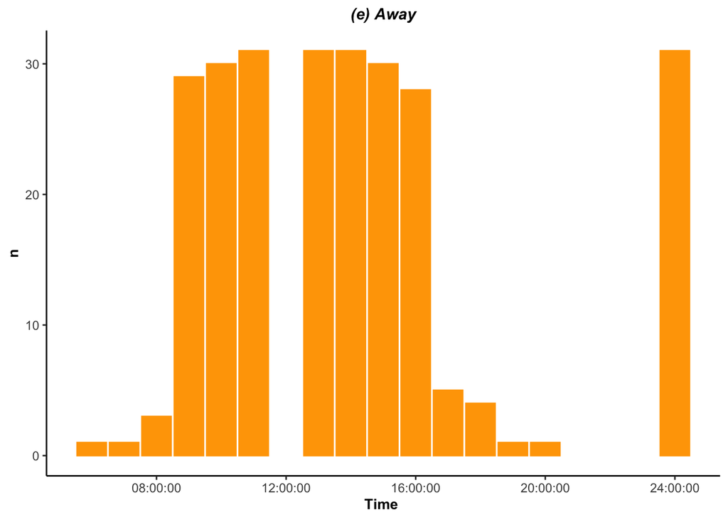

```r
e <- ggplot(tableAway, aes(x = fixedHMS, y = n)) + geom_bar(stat = "identity", position = "stack", color="orange", fill="orange") +
  ggtitle("(e) Away") +
  xlab("Time ") +
  ylab("n") + theme(plot.title = element_text(color="Black", size=11, face="bold.italic", hjust=0.5,lineheight=0.8),
        axis.title.x = element_text(color="black", size=10, face="bold"),
        axis.title.y = element_text(color="black", size=10, face="bold"),
        panel.background=element_rect(fill = "white"),
        panel.grid.minor = element_blank(),
        panel.grid.major = element_blank(),
        axis.line = element_line(colour = "black", size = 1) +
        scale_x_date(labels = date_format("%I:%M %p"))
)

e
```

## 2.6 Monday Transport

similar to the above but for transportation

> BA: table breaks for some reason?

```r
# creating dataframe for transportation

tableTransport <- monday %>%
  select(fixedHMS, Activity) %>%
  filter(Activity != "Sleeping") %>%
  filter(Activity != "Rest") %>%
  filter(Activity != "Work") %>%
  filter(Activity %in% c("Public transport", "Driving", "Walking")) %>%
  group_by(fixedHMS) %>%
  tally


tableTransport
```

```
## # A tibble: 0 x 2
## # … with 2 variables: fixedHMS <time>, n <int>
```

[figure not shown]

```r
#ploting Bar graph

f <- ggplot(tableTransport, aes(x = fixedHMS, y = n)) + geom_bar(stat = "identity", position = "stack", color="purple", fill="purple") +
  ggtitle("(e) Travelling") +
  xlab("Time ") +
  ylab("n") + theme(plot.title = element_text(color="Black", size=11, face="bold.italic", hjust=0.5,lineheight=0.8),
        axis.title.x = element_text(color="black", size=10, face="bold"),
        axis.title.y = element_text(color="black", size=10, face="bold"),
        panel.background=element_rect(fill = "white"),
        panel.grid.minor = element_blank(),
        panel.grid.major = element_blank(),
        axis.line = element_line(colour = "black", size = 1) +
        scale_x_date(labels = date_format("%I:%M %p"))
)

f
```

## 2.7 Monday Multiple plots

I wanted to put all the graphs in one page

```r
#graphs in one page

library(grid)
library(gridExtra)
library(gridBase)
```

> BA: I would do this a different way by re-coding and putting all the plots in one plot:

```r
# I would use data.table for this, not because it is the best way but because I know how to use it!
library(data.table)
mondayDT <- data.table::as.data.table(monday)
mondayDT[, ba_act := ifelse(Activity %in% c("Cooking", "Breakfast", "Dinner", "Light meal"),
                            "Cooking", # <- new code
                            NA)
         ]

mondayDT[, ba_act := ifelse(Activity %in% c("Tidy up", "Laundry", "Showering", "Getting dressed", "Ironing", "Feeding animals", "Turning off appliances/Lights"),
                            "Tidy up",
                            ba_act)
         ]

mondayDT[, ba_act := ifelse(Activity %in% c("TV", "Homework", "Laptop/PC", "Radio", "Mobile phones", "Reading", "Family time"),
                            "Leisure",
                            ba_act)
         ]

mondayDT[, ba_act := ifelse(Activity %in% c("Farm", "Relatives", "Work", "Fitness", "Kava", "Church", "Sports", "Going out"),
                            "Away",
                            ba_act)
         ]

mondayDT[, ba_act := ifelse(Activity %in% c("Public transport", "Driving", "Walking"),
                            "Transport",
                            ba_act)
         ]

t <- table(mondayDT$Activity, mondayDT$ba_act, useNA = "always")

kableExtra::kable(t, caption = "Test activity coding") %>%
  kable_styling()
```

Table 2.2: Test activity coding

|  | Away | Cooking | Leisure | Tidy up | NA |
| --- | --- | --- | --- | --- | --- |
| Breakfast | 0 | 7 | 0 | 0 | 0 |
| Church (social activities) | 0 | 0 | 0 | 0 | 1 |
| Cooking | 0 | 17 | 0 | 0 | 0 |
| Cooking (business) | 0 | 0 | 0 | 0 | 2 |
| Cooking (lunch) | 0 | 0 | 0 | 0 | 1 |
| Dinner | 0 | 16 | 0 | 0 | 0 |
| Driving (church) | 0 | 0 | 0 | 0 | 3 |
| Driving (drop kids) | 0 | 0 | 0 | 0 | 2 |
| Driving (drop relatives) | 0 | 0 | 0 | 0 | 1 |
| Driving (farm) | 0 | 0 | 0 | 0 | 1 |
| Driving (gym) | 0 | 0 | 0 | 0 | 8 |
| Driving (home) | 0 | 0 | 0 | 0 | 17 |
| Driving (pick up kids) | 0 | 0 | 0 | 0 | 5 |
| Driving (visiting relatives) | 0 | 0 | 0 | 0 | 5 |
| Driving (work) | 0 | 0 | 0 | 0 | 20 |
| Exercise (Jog, walk) | 0 | 0 | 0 | 0 | 2 |
| Family devotion | 0 | 0 | 0 | 0 | 5 |
| Family time (chatting, games etc) | 0 | 0 | 0 | 0 | 1 |
| Getting dressed | 0 | 0 | 0 | 8 | 0 |
| Getting dressed (kids) | 0 | 0 | 0 | 0 | 3 |
| Helping siblings (Homework) | 0 | 0 | 0 | 0 | 1 |
| Home | 0 | 0 | 0 | 0 | 15 |
| Homework (kids) | 0 | 0 | 0 | 0 | 11 |
| Ironing | 0 | 0 | 0 | 1 | 0 |
| Ironning | 0 | 0 | 0 | 0 | 1 |
| Kids bedtime | 0 | 0 | 0 | 0 | 3 |
| Laundry | 0 | 0 | 0 | 2 | 0 |
| Listen to music/radio | 0 | 0 | 0 | 0 | 1 |
| Mobile device (movies) | 0 | 0 | 0 | 0 | 13 |
| Mobile devices (work) | 0 | 0 | 0 | 0 | 6 |
| Mobile devises (browsing, social media) | 0 | 0 | 0 | 0 | 8 |
| Prepare kids bag for school | 0 | 0 | 0 | 0 | 1 |
| Public transport (home) | 0 | 0 | 0 | 0 | 1 |
| Public transport (work) | 0 | 0 | 0 | 0 | 1 |
| Reading | 0 | 0 | 4 | 0 | 0 |
| Rest | 0 | 0 | 0 | 0 | 8 |
| Showering | 0 | 0 | 0 | 14 | 0 |
| Sleeping | 0 | 0 | 0 | 0 | 233 |
| Tidy up | 0 | 0 | 0 | 7 | 0 |
| Turning off appliances/Lights | 0 | 0 | 0 | 1 | 0 |
| TV (TV, movies) | 0 | 0 | 0 | 0 | 25 |
| Use mobile devices | 0 | 0 | 0 | 0 | 2 |
| Walking (home) | 0 | 0 | 0 | 0 | 1 |
| Walking (work) | 0 | 0 | 0 | 0 | 3 |
| Wathing movies (TV) | 0 | 0 | 0 | 0 | 1 |
| Woke up | 0 | 0 | 0 | 0 | 22 |
| Work | 257 | 0 | 0 | 0 | 0 |
| NA | 0 | 0 | 0 | 0 | 0 |

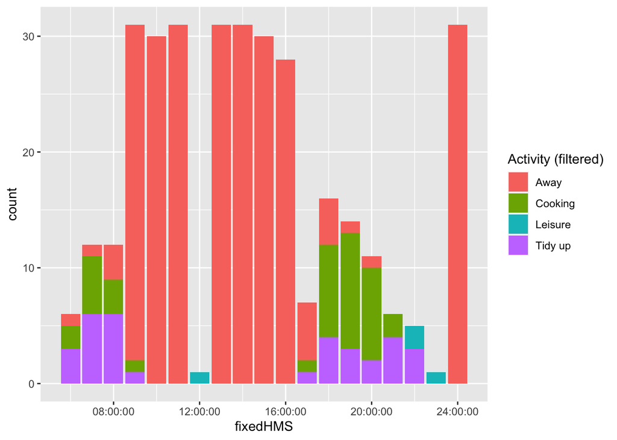

```r
# make a summary table for the plot
plotDT <- mondayDT[!is.na(ba_act), # excludes all NAs - see table to check coding
                   .(count = .N), keyby = .(fixedHMS, ba_act)]

ggplot2::ggplot(plotDT, aes(x = fixedHMS, y = count, fill = ba_act)) +
  geom_col() +
  scale_fill_discrete(name="Activity (filtered)")
```

# 3 All weekdays plotted using facets

Figure 3.1 shows counts for all days. We can see a few days are unkown. Also we have higher counts on Mondays. A lot of people are ‘out’ late at night?

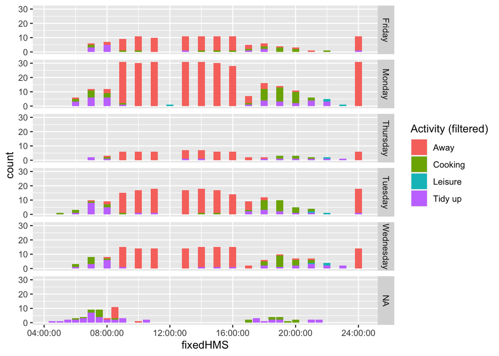

Figure 3.1: All days

```r
# use the all days table and the same coding method but across all days

allDaysDT <- data.table::as.data.table(newdata)
allDaysDT[, ba_act := ifelse(Activity %in% c("Cooking", "Breakfast", "Dinner", "Light meal"),
                            "Cooking", # <- new code
                            NA)
         ]

allDaysDT[, ba_act := ifelse(Activity %in% c("Tidy up", "Laundry", "Showering", "Getting dressed", "Ironing", "Feeding animals", "Turning off appliances/Lights"),
                            "Tidy up",
                            ba_act)
         ]

allDaysDT[, ba_act := ifelse(Activity %in% c("TV", "Homework", "Laptop/PC", "Radio", "Mobile phones", "Reading", "Family time"),
                            "Leisure",
                            ba_act)
         ]

allDaysDT[, ba_act := ifelse(Activity %in% c("Farm", "Relatives", "Work", "Fitness", "Kava", "Church", "Sports", "Going out"),
                            "Away",
                            ba_act)
         ]

allDaysDT[, ba_act := ifelse(Activity %in% c("Public transport", "Driving", "Walking"),
                            "Transport",
                            ba_act)
         ]

# t <- table(allDaysDT$Activity, allDaysDT$ba_act, useNA = "always")
#
# kableExtra::kable(t, caption = "Test activity coding (all days)") %>%
#   kable_styling()

# make a summary table for the plot
plotDT <- allDaysDT[!is.na(ba_act), # excludes all NAs - see table to check coding
                   .(count = .N), keyby = .(fixedHMS, ba_act, Day)]

ggplot2::ggplot(plotDT, aes(x = fixedHMS, y = count, fill = ba_act)) +
  geom_col() +
  facet_grid(Day ~ .) +
  scale_fill_discrete(name="Activity (filtered)")
```